# SMDS Homework - Block 4

C. Dorigo, R. Marvulli, A. Scardoni, L. Arrighi | Group ‘C’

29th April 2020

# DAAG EXERCISES

## Chapter 8

### Exercise 1

### Exercise 2

In the data set (an artificial one of 3121 patients, that is similar to a subset of the data analyzed in Stiell et al., 2001) minor.head.injury, obtain a logistic regression model relating clinically.important.brain.injury to other variables. Patients whose risk is sufficiently high will be sent for CT (computed tomography). Using a risk threshold of 0.025 (2.5%), turn the result into a decision rule for use of CT.

#### Solution

```r
library(DAAG)
library(stats)

# import data
data <- head.injury

# logistic model
model <- glm(clinically.important.brain.injury~.,data,
              family=binomial(link="logit"))
summary(model)
```

```
##
## Call:
## glm(formula = clinically.important.brain.injury ~ ., family = binomial(link = "logit"),
##     data = data)
##
## Deviance Residuals:
##     Min       1Q   Median       3Q      Max
## -2.2774  -0.3511  -0.2095  -0.1489   3.0028
##
## Coefficients:
##                       Estimate Std. Error z value Pr(>|z|)
## (Intercept)            -4.4972     0.1629 -27.611  < 2e-16 ***
## age.65                  1.3734     0.1827   7.518 5.56e-14 ***
## amnesia.before          0.6893     0.1725   3.996 6.45e-05 ***
## basal.skull.fracture    1.9620     0.2064   9.504  < 2e-16 ***
## GCS.decrease           -0.2688     0.3680  -0.730 0.465152
## GCS.13                  1.0613     0.2820   3.764 0.000168 ***
## GCS.15.2hours           1.9408     0.1663  11.669  < 2e-16 ***
## high.risk               1.1115     0.1591   6.984 2.86e-12 ***
## loss.of.consciousness   0.9554     0.1959   4.877 1.08e-06 ***
## open.skull.fracture     0.6304     0.3151   2.001 0.045424 *
## vomiting                1.2334     0.1961   6.290 3.17e-10 ***
## ---
## Signif. codes:  0 '***' 0.001 '**' 0.01 '*' 0.05 '.' 0.1 ' ' 1
##
## (Dispersion parameter for binomial family taken to be 1)
##
##     Null deviance: 1741.6  on 3120  degrees of freedom
## Residual deviance: 1201.3  on 3110  degrees of freedom
## AIC: 1223.3
##
## Number of Fisher Scoring iterations: 6
```

```r
# probability threshold 0.025 in terms of the linear model:
new_threshold <- log(0.025/(1-0.025))
new_threshold
```

```
## [1] -3.663562
```

```r
#needed increment to exceed threshold
increment <- new_threshold-unname(model$coefficients[1])
increment
```

```
## [1] 0.8336726
```

#### Observations

After importing the dataset I’ve fitted a logistic model relating `clinically.important.brain.injury` to all other variables. Through `summary()` function I can look at the results.

In order to convert the result of the logistic model into a rule for the use of CT, I’ve converted the probability threshold 0.025 in terms of the linear model applying the logit function so I can directly evaluate the effect of the covariates through their regression coefficients:
$$logit(0.025)=log\Big(\frac{0.025}{1-0.025}\Big)=-3.663562$$

The intercept of the fitted model is -4.4972 and it correspond to the value for an individual which has value 0 on all the covariates. In order to exceed the threshold we need an increment equal to 0.8336726. Now I can analyse which predictors (or prediction combinations) will lead to such increasement if they assume value 1.

### Exercise 6

As in the previous exercise, the function `poissonsim()` allows for experimentation with Poisson regression. In particular, `poissonsim()` can be used to simulate Poisson responses with log-rates equal to $a + bx$, where $a$ and $b$ are fixed values by default.

1. Simulate 100 Poisson responses using the model $log \lambda = 2 − 4x$ for $x = 0, 0.01, 0.02 ..., 1.0$. Fit a Poisson regression model to these data, and compare the estimated coefficients with the true coefficients. How well does the estimated model predict future observations?
2. Simulate 100 Poisson responses using the model $log \lambda = 2 − bx$ where $b$ is normally distributed with mean 4 and standard deviation 5. [Use the argument `slope.sd=5` in the `poissonsim()` function.] How do the results using the poisson and quasipoisson families differ?

#### (a)

```r
set.seed(2)

# simulate data from a poisson(exp{2-4x})
x <- seq(0,1,length=101)
data1 <- poissonsim(x,a=2,b=-4)

# fit a poisson regression model
poisson_model <- glm(y~x,data1,family=poisson(link="log"))
summary(poisson_model)
```

```
##
## Call:
## glm(formula = y ~ x, family = poisson(link = "log"), data = data1)
##
## Deviance Residuals:
##     Min       1Q   Median       3Q      Max
## -2.1215  -0.9048  -0.5231   0.5195   2.0365
##
## Coefficients:
##             Estimate Std. Error z value Pr(>|z|)
## (Intercept)   2.0285     0.1073   18.90   <2e-16 ***
## x            -4.0580     0.3508  -11.57   <2e-16 ***
## ---
## Signif. codes:  0 '***' 0.001 '**' 0.01 '*' 0.05 '.' 0.1 ' ' 1
##
## (Dispersion parameter for poisson family taken to be 1)
##
##     Null deviance: 280.430  on 100  degrees of freedom
## Residual deviance:  93.754  on  99  degrees of freedom
## AIC: 269.4
##
## Number of Fisher Scoring iterations: 5
```

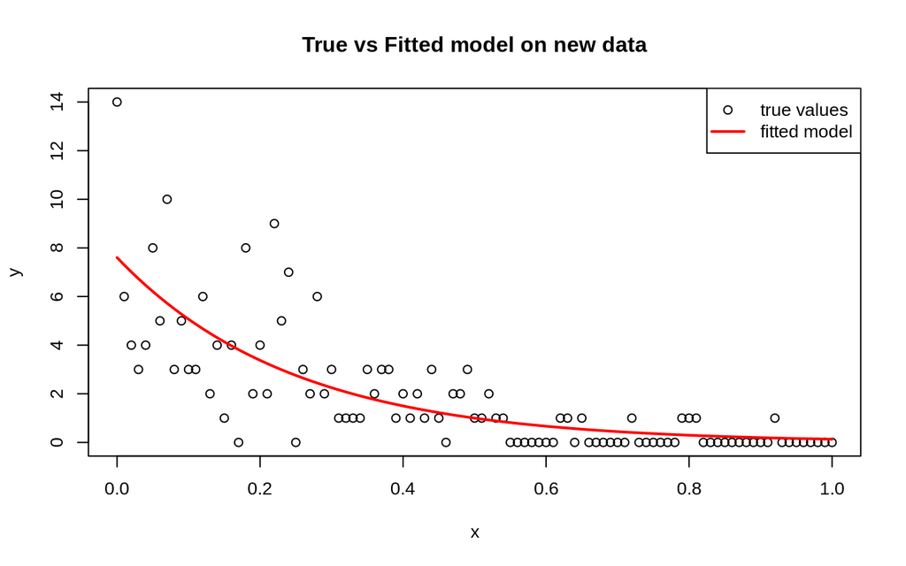

```r
# compare the true model and the fitted one on new data
new_data <- poissonsim(x,a=2,b=-4,seed=7)

# visually
set.seed(7) #change seed
predictions <- predict(poisson_model,newdata=new_data,type="response")
plot(x,new_data[,2],main="True vs Fitted model on new data",xlab="x",ylab="y")
lines(x,predictions,col=2,lwd=2)
legend("topright",legend=c("true values","fitted model"),
       col=c(1,2),lty=c(NA,1),pch=c(1,NA),lwd=c(NA,2))
```

```r
# computing deviance
# null deviance - all obs estimated with the mean
null_deviance <- sum((new_data[,2]-mean(new_data[,2]))^2)
null_deviance
```

```
## [1] 642.1386
```

```r
residual_deviance <- sum((new_data[,2]-predictions)^2)
residual_deviance
```

```
## [1] 272.2299
```

#### Observations

First of all I’ve simulated values from the given model:
$$log \lambda = 2-4x\\ y \sim Poisson(\lambda)$$

Then I’ve fitted a poisson regression model on the simulated data. Looking at the `summary()` function I can compare the true parameters $a=2$ and $b=-4$ with the estimated ones $\hat{a}=2.0285$ and $\hat{b}=-4.0580$. I can see tht they are really closed to the real values.

In order to check if the model works well on new data, I’ve changed the seed and I’ve sampled new values from the true model. Then I’ve compared them with the values obtained with the estimated model. From the last plot I can see that the model seems to work well also in predicting new data.

It can be seen also looking at the null and residual deviance computed on the new data.\ The null deviance is the deviance obtained with a model which includes only the intercept, a model in which for each observation the estimate is the sample mean of observed y. For new data the null deviance is 642.14. \ The residual deviance is the deviance obtained with the model we are evaluating. In our case we obtain a residual deviance equal to 272.23.\ With this model we are able to halve the deviance losing just one degree of freedom (we need to estimate the coefficient for x). It’s a worse result than with the original data where the residual deviance was about one third of the null deviance, but still a good result.

#### (b)

```r
set.seed(0)
# simulate data from a poisson(exp{2-bx}) where b~N(4,5)
data2 <- poissonsim(x,a=2,b=-4,slope.sd=4)
mean(data2[,2])
```

```
## [1] 4.841584
```

```r
var(data2[,2])
```

```
## [1] 235.4147
```

```r
# poisson regression model
pois_model <- glm(y~x,data2,family=poisson(link="log"))
summary(pois_model)
```

```
##
## Call:
## glm(formula = y ~ x, family = poisson(link = "log"), data = data2)
##
## Deviance Residuals:
##     Min       1Q   Median       3Q      Max
## -3.2547  -2.9861  -2.0616   0.2708  26.9969
##
## Coefficients:
##             Estimate Std. Error z value Pr(>|z|)
## (Intercept)  1.72445    0.08651  19.934   <2e-16 ***
## x           -0.30216    0.15547  -1.944   0.0519 .
## ---
## Signif. codes:  0 '***' 0.001 '**' 0.01 '*' 0.05 '.' 0.1 ' ' 1
##
## (Dispersion parameter for poisson family taken to be 1)
##
##     Null deviance: 1378.0  on 100  degrees of freedom
## Residual deviance: 1374.2  on  99  degrees of freedom
## AIC: 1583.2
##
## Number of Fisher Scoring iterations: 7
```

```r
#quasipoisson regression model
quasi_pois_model <- glm(y~x,data2,family=quasipoisson)
summary(quasi_pois_model)
```

```
##
## Call:
## glm(formula = y ~ x, family = quasipoisson, data = data2)
##
## Deviance Residuals:
##     Min       1Q   Median       3Q      Max
## -3.2547  -2.9861  -2.0616   0.2708  26.9969
##
## Coefficients:
##             Estimate Std. Error t value Pr(>|t|)
## (Intercept)   1.7244     0.6112   2.822  0.00578 **
## x            -0.3022     1.0984  -0.275  0.78381
## ---
## Signif. codes:  0 '***' 0.001 '**' 0.01 '*' 0.05 '.' 0.1 ' ' 1
##
## (Dispersion parameter for quasipoisson family taken to be 49.9105)
##
##     Null deviance: 1378.0  on 100  degrees of freedom
## Residual deviance: 1374.2  on  99  degrees of freedom
## AIC: NA
##
## Number of Fisher Scoring iterations: 7
```

#### Observations

The standard deviation is very high so I’m not surprised that the variability in the observations is high, in particular with respect to the mean (sample mean $= 4.84$ and sample variance $= 235.41$). So we are in an overdispersion situation which can be expressed using a quasi-poisson model:
$$\begin{cases}
E(y_i)=\lambda\\
Var(y_i)=\Phi E(y_i)\\
\end{cases}$$
where $\Phi$ is the overdispersion parameter.

The fitted poisson model does not take into account the overdispersion, indeed we can see from the summary of the model that the dispersion parameter is taken to be 1.

The fitted quasi-poisson model insted does take into account overdispersion and estimates this parameter to be equal to almost 50.

The estimated coefficients of the two models are the same and while the intercept is quite close to the real value ($\hat{a}=1.724, a=2$), the coefficient for x is very different from the real value ($\hat{b}=-0.302, b=-4$).